# Final Project Report

Omer Canca, Riley BLake, Ziyuan Ye

Due: December 15, 2021

## Clearing workspace and loading packages

```r
rm(list = ls())     # clean up your R environment

library(tidyverse)
library(dplyr)
library(rvest)
library(ggplot2)
library(ggformula)
library(stringr)
```

## Guiding Question:

What variables are good predictors for the price of cars and which are good variables for the price of motorcycles?

## Data Access

We begin by reading in the data files. Our first data file contains data regarding the price of cars and other variables such as make, fuel type, and doors. This data was posted by Eleanor Xu who posted it on Kaggle using Python. It was obtained 5 years ago from multiple open source datasets to analyze car prices and its variables. Data Link: URL: https://www.kaggle.com/jingbinxu/sample-of-car-data

Our second data file was gathered from Kaggle as well. It was posted by Nehal Birla who obtained it from multiple open source datasets in order to analyze motorcycle prices. She collected the data in 2020. It contains variables such as selling price, year, and seller type. URL: https://www.kaggle.com/nehalbirla/motorcycle-dataset

### Load data

```r
#Reading in our files
Cars <- read.csv("car_data.csv")
Bike <- read.csv("BIKE.csv")
```

### Inspect data

Viewing our datasets’ head and tail

```r
head(Cars)
```

|  | X | make | fuel_type | aspiration | num_of_doors | body_style | drive_wheels | engine_location | wheel_base | length | width | height | curb_weight | engine_type | num_of_cylinders | engine_size | fuel_system | compression_ratio | horsepower | peak_rpm | city_mpg | highway_mpg | price |
| --- | --- | --- | --- | --- | --- | --- | --- | --- | --- | --- | --- | --- | --- | --- | --- | --- | --- | --- | --- | --- | --- | --- | --- |
| 1 | 1 | alfa-romero | gas | std | two | convertible | rwd | front | 88.6 | 168.8 | 64.1 | 48.8 | 2548 | dohc | four | 130 | mpfi | 9.0 | 111 | 5000 | 21 | 27 | 13495 |
| 2 | 2 | alfa-romero | gas | std | two | convertible | rwd | front | 88.6 | 168.8 | 64.1 | 48.8 | 2548 | dohc | four | 130 | mpfi | 9.0 | 111 | 5000 | 21 | 27 | 16500 |
| 3 | 3 | alfa-romero | gas | std | two | hatchback | rwd | front | 94.5 | 171.2 | 65.5 | 52.4 | 2823 | ohcv | six | 152 | mpfi | 9.0 | 154 | 5000 | 19 | 26 | 16500 |
| 4 | 4 | audi | gas | std | four | sedan | fwd | front | 99.8 | 176.6 | 66.2 | 54.3 | 2337 | ohc | four | 109 | mpfi | 10.0 | 102 | 5500 | 24 | 30 | 13950 |
| 5 | 5 | audi | gas | std | four | sedan | 4wd | front | 99.4 | 176.6 | 66.4 | 54.3 | 2824 | ohc | five | 136 | mpfi | 8.0 | 115 | 5500 | 18 | 22 | 17450 |
| 6 | 6 | audi | gas | std | two | sedan | fwd | front | 99.8 | 177.3 | 66.3 | 53.1 | 2507 | ohc | five | 136 | mpfi | 8.5 | 110 | 5500 | 19 | 25 | 15250 |

```r
tail(Cars)
```

|  | X | make | fuel_type | aspiration | num_of_doors | body_style | drive_wheels | engine_location | wheel_base | length | width | height | curb_weight | engine_type | num_of_cylinders | engine_size | fuel_system | compression_ratio | horsepower | peak_rpm | city_mpg | highway_mpg | price |
| --- | --- | --- | --- | --- | --- | --- | --- | --- | --- | --- | --- | --- | --- | --- | --- | --- | --- | --- | --- | --- | --- | --- | --- |
| 200 | 200 | volvo | gas | turbo | four | wagon | rwd | front | 104.3 | 188.8 | 67.2 | 57.5 | 3157 | ohc | four | 130 | mpfi | 7.5 | 162 | 5100 | 17 | 22 | 18950 |
| 201 | 201 | volvo | gas | std | four | sedan | rwd | front | 109.1 | 188.8 | 68.9 | 55.5 | 2952 | ohc | four | 141 | mpfi | 9.5 | 114 | 5400 | 23 | 28 | 16845 |
| 202 | 202 | volvo | gas | turbo | four | sedan | rwd | front | 109.1 | 188.8 | 68.8 | 55.5 | 3049 | ohc | four | 141 | mpfi | 8.7 | 160 | 5300 | 19 | 25 | 19045 |
| 203 | 203 | volvo | gas | std | four | sedan | rwd | front | 109.1 | 188.8 | 68.9 | 55.5 | 3012 | ohcv | six | 173 | mpfi | 8.8 | 134 | 5500 | 18 | 23 | 21485 |
| 204 | 204 | volvo | diesel | turbo | four | sedan | rwd | front | 109.1 | 188.8 | 68.9 | 55.5 | 3217 | ohc | six | 145 | idi | 23.0 | 106 | 4800 | 26 | 27 | 22470 |
| 205 | 205 | volvo | gas | turbo | four | sedan | rwd | front | 109.1 | 188.8 | 68.9 | 55.5 | 3062 | ohc | four | 141 | mpfi | 9.5 | 114 | 5400 | 19 | 25 | 22625 |

```r
head(Bike)
```

|  | name | selling_price | year | seller_type | owner | km_driven | ex_showroom_price |
| --- | --- | --- | --- | --- | --- | --- | --- |
| 1 | Royal Enfield Classic 350 | 175000 | 2019 | Individual | 1st owner | 350 | NA |
| 2 | Honda Dio | 45000 | 2017 | Individual | 1st owner | 5650 | NA |
| 3 | Royal Enfield Classic Gunmetal Grey | 150000 | 2018 | Individual | 1st owner | 12000 | 148114 |
| 4 | Yamaha Fazer FI V 2.0 [2016-2018] | 65000 | 2015 | Individual | 1st owner | 23000 | 89643 |
| 5 | Yamaha SZ [2013-2014] | 20000 | 2011 | Individual | 2nd owner | 21000 | NA |
| 6 | Honda CB Twister | 18000 | 2010 | Individual | 1st owner | 60000 | 53857 |

```r
tail(Bike)
```

|  | name | selling_price | year | seller_type | owner | km_driven | ex_showroom_price |
| --- | --- | --- | --- | --- | --- | --- | --- |
| 1056 | Bajaj ct 100 | 18000 | 2017 | Individual | 1st owner | 35000 | 32000 |
| 1057 | Activa 3g | 17000 | 2010 | Individual | 1st owner | 500000 | 52000 |
| 1058 | Honda CB twister | 16000 | 2012 | Individual | 1st owner | 33000 | 51000 |
| 1059 | Bajaj Discover 125 | 15000 | 2013 | Individual | 2nd owner | 35000 | 57000 |
| 1060 | Honda CB Shine | 12000 | 2009 | Individual | 1st owner | 53000 | 58000 |
| 1061 | Bajaj Pulsar 150 | 10000 | 2008 | Individual | 1st owner | 92233 | 75000 |

Analyzing our variables for Cars

```r
ls(Cars)
```

```
 [1] "aspiration"        "body_style"        "city_mpg"          "compression_ratio" "curb_weight"
 [6] "drive_wheels"      "engine_location"   "engine_size"       "engine_type"       "fuel_system"
[11] "fuel_type"         "height"            "highway_mpg"       "horsepower"        "length"
[16] "make"              "num_of_cylinders"  "num_of_doors"      "peak_rpm"          "price"
[21] "wheel_base"        "width"             "X"
```

Analyzing our variables for Bike

```r
ls(Bike)
```

```
[1] "ex_showroom_price" "km_driven"         "name"              "owner"             "seller_type"
[6] "selling_price"     "year"
```

Analyzing our variable types for Cars

```r
str(Cars)
```

```
'data.frame':   205 obs. of  23 variables:
 $ X                : int  1 2 3 4 5 6 7 8 9 10 ...
 $ make             : chr  "alfa-romero" "alfa-romero" "alfa-romero" "audi" ...
 $ fuel_type        : chr  "gas" "gas" "gas" "gas" ...
 $ aspiration       : chr  "std" "std" "std" "std" ...
 $ num_of_doors     : chr  "two" "two" "two" "four" ...
 $ body_style       : chr  "convertible" "convertible" "hatchback" "sedan" ...
 $ drive_wheels     : chr  "rwd" "rwd" "rwd" "fwd" ...
 $ engine_location  : chr  "front" "front" "front" "front" ...
 $ wheel_base       : num  88.6 88.6 94.5 99.8 99.4 ...
 $ length           : num  169 169 171 177 177 ...
 $ width            : num  64.1 64.1 65.5 66.2 66.4 66.3 71.4 71.4 71.4 67.9 ...
 $ height           : num  48.8 48.8 52.4 54.3 54.3 53.1 55.7 55.7 55.9 52 ...
 $ curb_weight      : int  2548 2548 2823 2337 2824 2507 2844 2954 3086 3053 ...
 $ engine_type      : chr  "dohc" "dohc" "ohcv" "ohc" ...
 $ num_of_cylinders : chr  "four" "four" "six" "four" ...
 $ engine_size      : int  130 130 152 109 136 136 136 136 131 131 ...
 $ fuel_system      : chr  "mpfi" "mpfi" "mpfi" "mpfi" ...
 $ compression_ratio: num  9 9 9 10 8 8.5 8.5 8.5 8.3 7 ...
 $ horsepower       : chr  "111" "111" "154" "102" ...
 $ peak_rpm         : chr  "5000" "5000" "5000" "5500" ...
 $ city_mpg         : int  21 21 19 24 18 19 19 19 17 16 ...
 $ highway_mpg      : int  27 27 26 30 22 25 25 25 20 22 ...
 $ price            : chr  "13495" "16500" "16500" "13950" ...
```

Analyzing our variable types for Bike

```r
str(Bike)
```

```
'data.frame':   1061 obs. of  7 variables:
 $ name             : chr  "Royal Enfield Classic 350" "Honda Dio" "Royal Enfield Classic Gunmetal Grey" "Yamaha Fazer FI V 2.0 [2016-2018]" ...
 $ selling_price    : int  175000 45000 150000 65000 20000 18000 78500 180000 30000 50000 ...
 $ year             : int  2019 2017 2018 2015 2011 2010 2018 2008 2010 2016 ...
 $ seller_type      : chr  "Individual" "Individual" "Individual" "Individual" ...
 $ owner            : chr  "1st owner" "1st owner" "1st owner" "1st owner" ...
 $ km_driven        : int  350 5650 12000 23000 21000 60000 17000 39000 32000 42000 ...
 $ ex_showroom_price: int  NA NA 148114 89643 NA 53857 87719 NA NA 60122 ...
```

## Data Wrangling

We performed a series of data wrangling to help us better understand the data and create better visualizations. These included regular expressions, user-defined functions, reduction/transformation functions, and pivots.

### Convert owner’s data type

We decide to change the number of owners from a character to numeric variable. For example, one owner will become “1” and so on. This allows us to find the mean number of owners.

```r
Bike <-
  Bike %>%
    mutate(owner = gsub(pattern = "[st,nd,rd,th]|owner", replacement = "", owner))
```

```r
Bike$owner <- as.numeric(as.character(Bike$owner))
```

```r
str(Bike) #testing
```

```
'data.frame':   1061 obs. of  7 variables:
 $ name             : chr  "Royal Enfield Classic 350" "Honda Dio" "Royal Enfield Classic Gunmetal Grey" "Yamaha Fazer FI V 2.0 [2016-2018]" ...
 $ selling_price    : int  175000 45000 150000 65000 20000 18000 78500 180000 30000 50000 ...
 $ year             : int  2019 2017 2018 2015 2011 2010 2018 2008 2010 2016 ...
 $ seller_type      : chr  "Individual" "Individual" "Individual" "Individual" ...
 $ owner            : num  1 1 1 1 2 1 1 2 1 1 ...
 $ km_driven        : int  350 5650 12000 23000 21000 60000 17000 39000 32000 42000 ...
 $ ex_showroom_price: int  NA NA 148114 89643 NA 53857 87719 NA NA 60122 ...
```

```r
mean(Bike$owner,na.rm = TRUE)
```

```
[1] 1.145146
```

### Finding the square inches of cars

```r
sqr_length <- function(a,b,c){
  (a*b*c)
}
Cars$square_inches <- sqr_length(Cars$length,Cars$width,Cars$height)
intoft <- function(a){
  (a/12)
}
Cars$length_ft <- intoft(Cars$length)
Cars$width_ft <- intoft(Cars$width)
Cars$height_ft <- intoft(Cars$height)
Cars$square_inches <- sqr_length(Cars$length_ft,Cars$width_ft,Cars$height_ft)
Cars
```

| X | make | fuel_type | aspiration | num_of_doors | body_style | drive_wheels | engine_location | wheel_base | length | width | height | curb_weight | engine_type | num_of_cylinders | engine_size | fuel_system | compression_ratio | horsepower | peak_rpm | city_mpg | highway_mpg | price | square_inches | length_ft | width_ft | height_ft |
| --- | --- | --- | --- | --- | --- | --- | --- | --- | --- | --- | --- | --- | --- | --- | --- | --- | --- | --- | --- | --- | --- | --- | --- | --- | --- | --- |
| 1 | alfa-romero | gas | std | two | convertible | rwd | front | 88.6 | 168.8 | 64.1 | 48.8 | 2548 | dohc | four | 130 | mpfi | 9.00 | 111 | 5000 | 21 | 27 | 13495 | 305.5671 | 14.06667 | 5.341667 | 4.066667 |
| 2 | alfa-romero | gas | std | two | convertible | rwd | front | 88.6 | 168.8 | 64.1 | 48.8 | 2548 | dohc | four | 130 | mpfi | 9.00 | 111 | 5000 | 21 | 27 | 16500 | 305.5671 | 14.06667 | 5.341667 | 4.066667 |
| 3 | alfa-romero | gas | std | two | hatchback | rwd | front | 94.5 | 171.2 | 65.5 | 52.4 | 2823 | ohcv | six | 152 | mpfi | 9.00 | 154 | 5000 | 19 | 26 | 16500 | 340.0420 | 14.26667 | 5.458333 | 4.366667 |
| 4 | audi | gas | std | four | sedan | fwd | front | 99.8 | 176.6 | 66.2 | 54.3 | 2337 | ohc | four | 109 | mpfi | 10.00 | 102 | 5500 | 24 | 30 | 13950 | 367.3709 | 14.71667 | 5.516667 | 4.525000 |
| 5 | audi | gas | std | four | sedan | 4wd | front | 99.4 | 176.6 | 66.4 | 54.3 | 2824 | ohc | five | 136 | mpfi | 8.00 | 115 | 5500 | 18 | 22 | 17450 | 368.4808 | 14.71667 | 5.533333 | 4.525000 |
| 6 | audi | gas | std | two | sedan | fwd | front | 99.8 | 177.3 | 66.3 | 53.1 | 2507 | ohc | five | 136 | mpfi | 8.50 | 110 | 5500 | 19 | 25 | 15250 | 361.2210 | 14.77500 | 5.525000 | 4.425000 |
| 7 | audi | gas | std | four | sedan | fwd | front | 105.8 | 192.7 | 71.4 | 55.7 | 2844 | ohc | five | 136 | mpfi | 8.50 | 110 | 5500 | 19 | 25 | 17710 | 443.4977 | 16.05833 | 5.950000 | 4.641667 |
| 8 | audi | gas | std | four | wagon | fwd | front | 105.8 | 192.7 | 71.4 | 55.7 | 2954 | ohc | five | 136 | mpfi | 8.50 | 110 | 5500 | 19 | 25 | 18920 | 443.4977 | 16.05833 | 5.950000 | 4.641667 |
| 9 | audi | gas | turbo | four | sedan | fwd | front | 105.8 | 192.7 | 71.4 | 55.9 | 3086 | ohc | five | 131 | mpfi | 8.30 | 140 | 5500 | 17 | 20 | 23875 | 445.0902 | 16.05833 | 5.950000 | 4.658333 |
| 10 | audi | gas | turbo | two | hatchback | 4wd | front | 99.5 | 178.2 | 67.9 | 52.0 | 3053 | ohc | five | 131 | mpfi | 7.00 | 160 | 5500 | 16 | 22 | ? | 364.1137 | 14.85000 | 5.658333 | 4.333333 |

[output cut: 195 more lines]

### Prepare a subdata for aspiration visualization (regular expression and pivot)

```r
### Prepare a subdata for brand visualization (regular expression and transfornmation function)

Cars <- Cars[Cars$price != '?',] #we want the cases with price only
Cars$price <- as.numeric(Cars$price)

Cars <- # adjust with currency exchange rate
  Cars %>%
  mutate(price = 1.2*price)

Make <-
  Cars %>%
  select(make, price) %>%
  group_by(make) %>%
  summarise(mean_price_New = mean(price,na.rm = T)) %>%
  mutate(valuegroup = if_else(mean_price_New > 30000, true = "> $30k",
                              false = if_else(mean_price_New >15000,
                                              true = "$30k-$15k",
                                              false = "< $15k"))) %>%
  # define price group for new cars
  arrange(desc(mean_price_New))

Aspiration <-
  Cars %>%
  group_by(make, aspiration) %>%
  summarise(total = mean(price)) %>%
  pivot_wider(names_from = aspiration, values_from = total)
```

## Data Visualization

### Relationship between manufacturers and car/motorcycle price

First, we would like to see which manufacturers have the highest average price of cars and motorcycles.

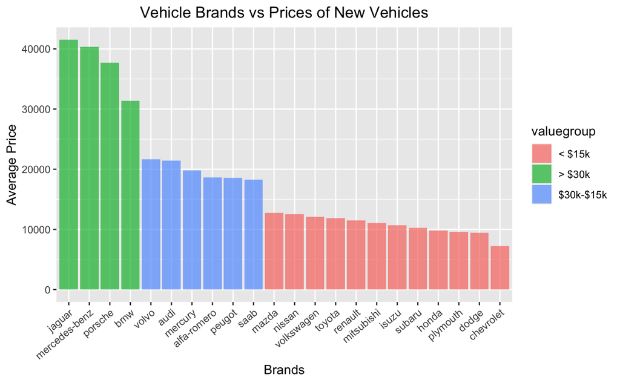

```r
# Bar chart displays the average car price of each brand
MakevsPrice <-
  ggplot(Make) +
  aes(x = reorder(make, desc(mean_price_New)),weight = mean_price_New, fill = valuegroup) +
  geom_bar(alpha = 0.7) +
  xlab("Brands") +
  ylab("Average Price") +
  ggtitle(label = "Vehicle Brands vs Prices of New Vehicles") +
  theme(axis.text.x = element_text(angle = 40, hjust = 1)) +
  theme(plot.title = element_text(hjust = 0.5))
MakevsPrice
```

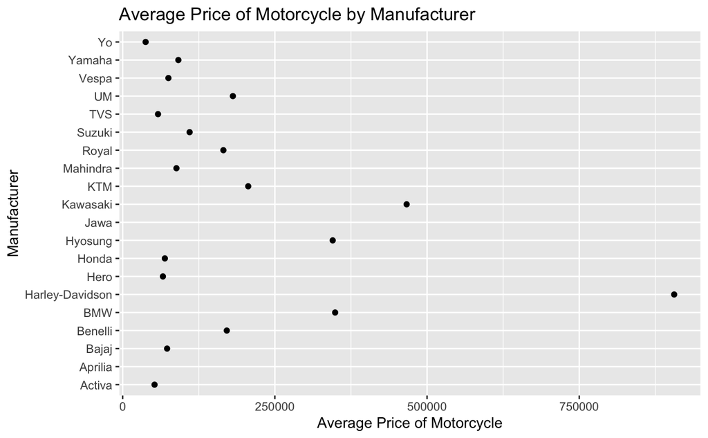

```r
Bike$manufacturer <- word(Bike$name, 1) # Making a column with just the manufacturer
Bike%>%
  group_by(manufacturer) %>%
  summarise(AveragePrice = mean(ex_showroom_price, na.rm = TRUE)) %>%
  arrange(desc(AveragePrice)) %>%
  ggplot(aes(x = AveragePrice, y = manufacturer)) + geom_point() + ylab("Manufacturer") + xlab("Average Price of Motorcycle") + ggtitle("Average Price of Motorcycle by Manufacturer")
```

We discover that price is highly influenced by manufacturer. Top 3 most expensive manufacturers for Cars: Jaguar, Mercedes-Benz, Porsche Top 3 most expensive manufacturers for Motorcycles: Harley-Davidson, Kawasaki, BMW

### Relationship between Price and Seller Type and Year in Motorcycles

Next we analyze if owner and year can influence the price of motorcycles.

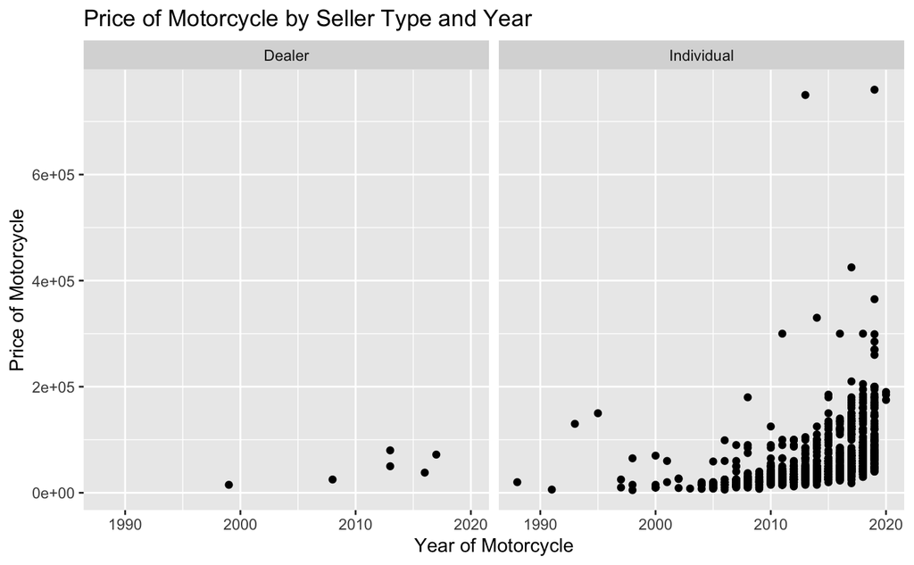

```r
Bike%>%
  ggplot(aes(x = year, y = selling_price)) + geom_point() + facet_grid( ~ seller_type)  + ylab("Price of Motorcycle") + xlab("Year of Motorcycle") + ggtitle("Price of Motorcycle by Seller Type and Year")
```

From this graph, we can see that as a motorcycle increases year, the price increases This is likely due to the wear that is put on an older motorcycle. Older motorcycles have a lower price while newer ones have higher ones. We cannot say that seller type can influence price. There is not information to say that it would be true. However, Year and Price have a positive linear relationship.

### Relationship between kilometers driven, price, and owners in Motorcycles

```
Warning: Removed 827 rows containing non-finite values (stat_smooth).
Warning: Removed 827 rows containing missing values (geom_point).
```

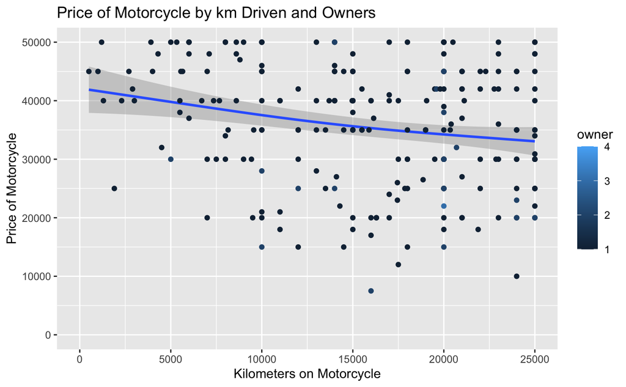

```r
Bike%>%
  ggplot(aes(x = km_driven, y = selling_price, color = owner)) + geom_smooth() + geom_point()+ ylab("Price of Motorcycle") + xlab("Kilometers on Motorcycle") + ggtitle("Price of Motorcycle by km Driven and Owners") + xlim(0, 25000)+ ylim(0, 50000)
```

We find that as kilometers on a motorcycle increases, the price of it decreases. This is likely due to the wear and tear that kilomters put on a bike.

### Relationship between square inches and price in a car

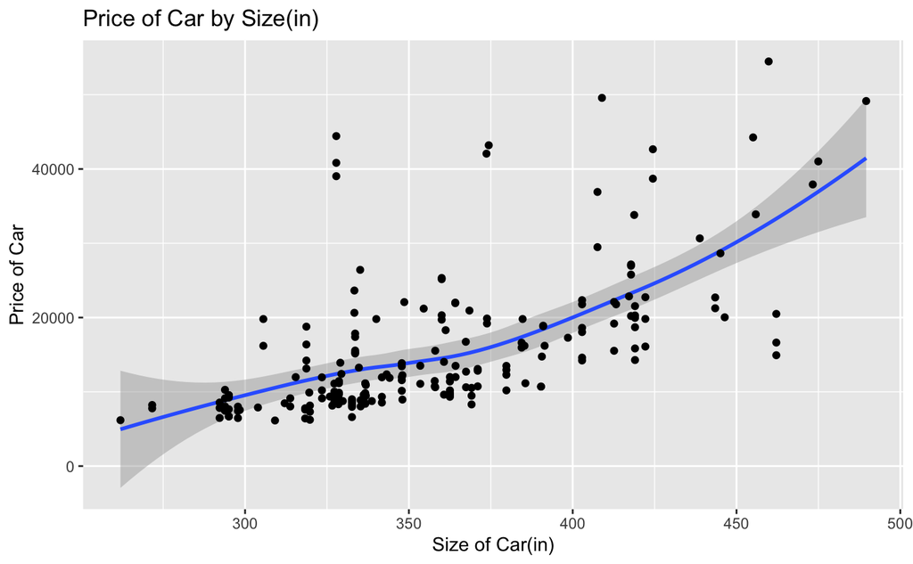

```r
 Cars%>%
   ggplot(aes(x = square_inches, y = price)) + geom_smooth() + geom_point()+ ylab("Price of Car") + xlab("Size of Car(in)") + ggtitle("Price of Car by Size(in)")
```

Using our function, we see that as the size of a car increases, the price of increases. Larger cars provide more space and are much more likely to be expensive. Size and price have a positive linear relationship.

### Difference between turbo engine and standard engine in cars

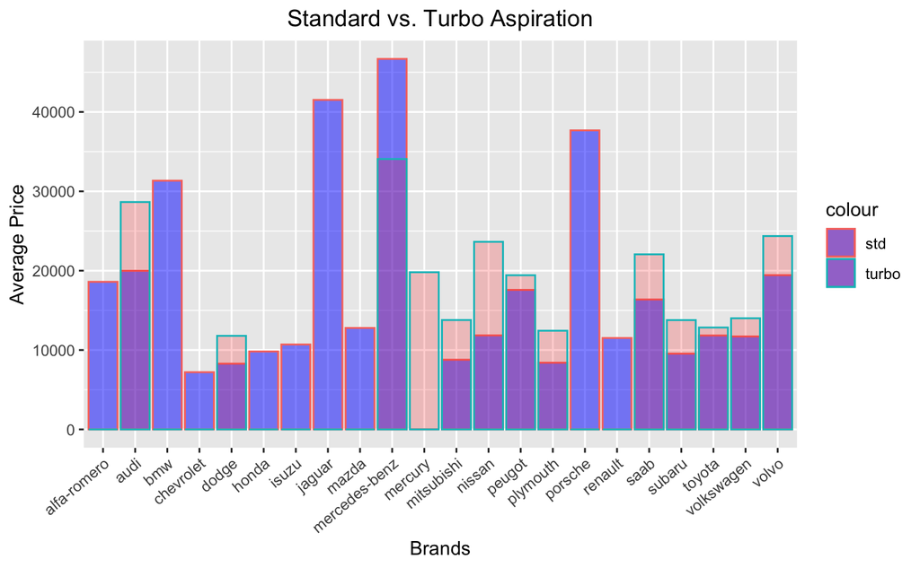

```r
AspirationComp <-
  ggplot(Aspiration, aes(x = make)) +
  geom_bar(fill = "blue", alpha = 0.5, aes(weight = std, color = "std")) +
  geom_bar(fill = "red", alpha = 0.2, aes(weight = turbo, color = "turbo")) +
  xlab("Brands") +
  ylab("Average Price") +
  ggtitle(label = "Standard vs. Turbo Aspiration") +
  theme(axis.text.x = element_text(angle = 40, hjust = 1)) +
  theme(plot.title = element_text(hjust = 0.5))
AspirationComp
```

From the graph above, we find that cars from the same brand with turbo engines usually have a higher prices than the standard engines. When purchasing vehicles, we shall compare the price with products from the same brand according to the engine type.

### Deeper look at Owners and Price Relationship in Motorcycles.

```
Warning: Removed 480 rows containing non-finite values (stat_smooth).
Warning: Removed 480 rows containing non-finite values (stat_boxplot).
```

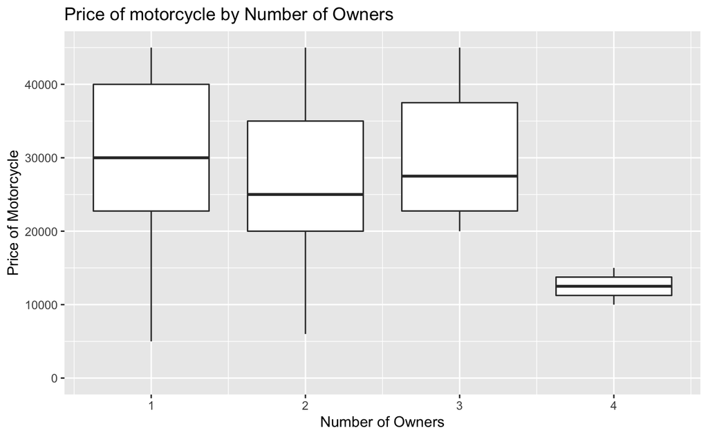

```r
Bike%>%
  ggplot(aes(x=owner,group=owner, y = selling_price)) + geom_smooth() + geom_boxplot()+ ylab("Price of Motorcycle") + xlab("Number of Owners") + ggtitle("Price of motorcycle by Number of Owners") + ylim(0,45000)
```

# Conclusion

### We find that the following variables are good for predicting price in cars:

Manufacturers: Luxury brand manufacturers are more likely to have more expensive cars. Square Inches: Size and price have a positive linear relationship. Larger cars aare more likely to be expensive because they provide more room.

### Not so good variables for predicting price in motorcycles:

Seller type: This is not a good indicator of price of motorcycles. This is due to there not being a large change in price based on if the motorcycle is sold by a dealer or by an individual. Number of owners: This is not a good indicator of price for motorcycle price because of the conflicting data that there are both positive and negative reasons for a person to sell their motorcycle (rarity, problems)